# NTHMP1: Submerged Island Lab, using River forcing

This test is based on a laboratory experiment of shallow water flow above a canonical island, and aim to reproduce and compare the Von Karmann alley observed downstream of the island. The test case is the first of the benchmak problems proposed at the [2015 NTHMP workshop](http://coastal.usc.edu/currents_workshop/problems/prob1.html). For this testcase, a forcing in velocity is required. As BG_Flood does not propose this type of boundary condition, a river forcing (implemented in the code as a vertical discharge over an area) is used. The river forcing is progressively increased to avoid the formation of a front and reflected waves in the domain.

## Pyton set-up

As this notebook is based on Python, please installed the dependencies listed in the *.yml file: *BG_flood_testing.yml* .

```python
import numpy as np
import matplotlib.pyplot as plt
import xarray as xr
import os
import shutil
from netCDF4 import Dataset
import netCDF4 as nc4
from zipfile import ZipFile
from io import BytesIO
import urllib.request

## Read text file given its name (and path), number of columns, number of header lines
def readCSV_Ncol(name,n_col,n_pass):
    X=[]
    for i in range(n_col):
        X.append([])

    f=open(name,'r')
    n_line=0
    for line in f.readlines():
        if n_line<n_pass:
            n_line = n_line+1
        else:
            sline=line.split()
            for i in range(n_col):
                X[i].append(float(sline[i]))
    f.close()
    return(X)

## Download from url
def download_url(url, save_path):
    with urllib.request.urlopen(url) as dl_file:
        with open(save_path, 'wb') as out_file:
            out_file.write(dl_file.read())

MyDir = os.getcwd()
```

```python
##os.chdir('.\\NTHMP1')
```

```python
MyDir = os.getcwd()
```

## Location of the code executable

The variable codeDir contains a compiled version of the BG_Flood (*BG_Flood.exe*) and the associated needed links to the libraries (*.dll files).

```python
codeDir = r"C:\Users\haranga\BG-Flood\Test_Cases_Alice\CodeDir"
```

### Getting the benchmark data from online website

The Benchmark data is located in a zip on the benchmark website.

```python
download_url('http://coastal.usc.edu/currents_workshop/all_data.zip', 'all_data.zip')
```

```python
with ZipFile('all_data.zip', 'r') as zipObj:
   # Get a list of all archived file names from the zip
   listOfFileNames = zipObj.namelist()
```

```python
with ZipFile('all_data.zip', 'r') as zipObj:
    zipObj.extract('1_Submerged_Island_Lab/comparison_data/SL_S1_U.DAT')
    zipObj.extract('1_Submerged_Island_Lab/comparison_data/SL_S1_V.DAT')
    zipObj.extract('1_Submerged_Island_Lab/comparison_data/SL_S2_U.DAT')
    zipObj.extract('1_Submerged_Island_Lab/comparison_data/SL_S2_V.DAT')
```

```python
dataDir = os.path.join(MyDir,'1_Submerged_Island_Lab')
```

## Creation of the bathymetry

The bathymetry is defined by the geometry of the island, its position and the size of the simulation domain. It is created and saved in a netcdf file (classic topography/bathymetry input for BG_Flood).

### Creation of the numerical domain

```python
dx=0.01
xo=0
xf=9.84
nx=int((xf-xo)/dx)
x=np.linspace(xo, xf, nx)
yo=0
yf=1.52
ny=int((yf-yo)/dx)
y=np.linspace(yo, yf, ny)
```

### Addition of the island from the paper definition

```python
xi=5.0;
yi=1.52/2;
slope_d=8;
base_r=0.75/2;
top_r=0.05/2;
hi=0.049;

z= np.zeros((ny,nx))

for i in range(nx):
    for j in range (ny):
        dist=np.sqrt((x[i]-xi)**2+(y[j]-yi)**2);
        if dist<base_r:
            z[j,i] = np.min([hi,hi*(1-(dist-top_r)/(base_r-top_r))])
```

### Plot of the bathymetry

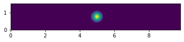

```python
X,Y = np.meshgrid(x,y)
plt.pcolormesh(X,Y,z, shading='auto')
plt.axis('scaled')
plt.savefig('bathymetry.png')
fig1=plt.gcf()
plt.show()
```

### Save the Bathymetry as a netCDF file

```python
ds = xr.Dataset(
      {"z": (("y", "x"), z)},
      coords={
          "x": x,
          "y": y,
      },
  )

ds.to_netcdf("bathy.nc")
```

## Creation of the forcing

BG_flood does not possess a velocity forcing (*yet*). The simulation will then be forced using a "river" discharge along the left boundary, and a wall boundary condition on this boundary. As this water discharge lead to an increase of 0.0095m of the water elevation at the left boundary (and no any other water elevation are fixed in this simulation), the initial water elevation will be adjust to obtain the expected value.

```python
h = 0.054
hinit = 0.054-0.0095
hinit
```

```
0.0445
```

## Writing the river forcing file

The velocity forcing will be applied using the river forcing module. The forcing is applied as a vertical discharge ($m^3/s$) on the first line(s) of cells along the left boundary. The left boundary type associated is a wall. To avoid a hard front and the creation of reflected waves in the domain, the discharge is linearly increased during the first 45s of the simulation

```python
Vi = 0.115
t = [0,45,180]
h = 0.054
A = h * (yf-yo);
Q = A * Vi;

filename = "river_forcing.txt"
f=open(filename,'w')
f.write('%f \t %f \n' % (t[0],0))
f.write('%f \t %f \n' % (t[1],Q))
f.write('%f \t %f \n' % (t[2],Q))
f.close()
Q
```

```
0.0094392
```

## Writing the BG_Params file

This text file is the main interface to BG_Flood. It contains a list of key words and associated values to modify the default flow and grid and time keeping parameters, boundary and external forcing, as well as output options and reference values. Different keys can be accepted for the same parameter (see the documentation for a detailled list of the input parameters). The minimum input is the bathymetry file. In this example, we will conserve a simple version of the BG_Params file where only the modified values will be listed:

```python
key=[]
value=[]
```

- name of the bathymetry file (and variable name associated to altitude (here *z*) if the format is netCDF)

```python
key.append('topofile')
value.append('bathy.nc?z')
```

- Timekeeping parameters
  - "totaltime" : Start time for the simulation
  - "endtime" : End of simulation (in s)

```python
key.append('totaltime')
value.append(t[0])
key.append('endtime')
value.append(t[-1])
```

- Grid parameters: By default, the parameters of the topography map is used (to determine the resolution (dx) and the borders of the domain). Here, we will enforce it. In that case, we need to make sure that the number of cells in the x and y direction is a multiple of the number of cells in a block (16 by default).
  - "dx" : x and y resolution (square cells)
  - "xo", "xmax", "yo", "ymax": coordinate of the corners of the grid

```python
key.append('dx')
value.append(0.005000)
key.append('xo')
value.append(xo)
key.append('xmax')
value.append(xf)
key.append('yo')
value.append(yo)
key.append('ymax')
value.append(yf)
```

- Flow and models parameters
  - "frictionmodel": bottom friction model (-1: Manning model, 0:, 1: Smart model (default, **REF**))
  - cf: friction coefficient
  - "eps": minimum water elevation

```python
key.append('frictionmdel')
value.append('-1')
key.append('cf')
value.append('0.01')
value.append('0.000001')
key.append('eps')
```

- Boundaries condition Boundaries are refered by their position, using "top/bottom/right/left" keywords. They are associated to a boundary type ( 0:wall; 1: Neumann (Default); 2:Dirichlet (zs); 3: abs1d) and possibly a file containing a time serie.

```python
key.append('left')
value.append('0')
key.append('top')
value.append('0')
key.append('bottom')
value.append('0')
key.append('right')
value.append('1')
```

- Initial conditions:
  - "zinit" : initial water level

```python
key.append('zsinit')
value.append(hinit)
```

```python
key.append('river')
value.append('river_forcing.txt,-0.00001,0.51,-0.00001,1.53')
```

- Outputs The code can output 2D map of 2D fields in netCDF format and time series of water elevation.
  - "outputtimestep" : Time step for 2D fields outputs
  - "smallnc": to scaled and saved 2D fields as a short integer if 1 (default value)
  - "TSOutput": Time serie output, giving a file name and a (x,y) position (which will be converted to nearest grid position). This keyword can be used multiple times to extract time series at different locations.

```python
key.append('outputtimestep')
value.append('2')
key.append('smallnc')
value.append('0')
key.append('TSOutput')
value.append('gauge_centered.txt,6.02,0.76')
key.append('TSOutput')
value.append('gauge_offset.txt,6.02,1.03')
key.append('TSOutput')
value.append('gauge_forcing.txt,4.4,0.76')
```

```python
key
```

[output not shown]

```python
value
```

[output not shown]

These data are then saved in a BG_Param.txt file.

```python
data = np.column_stack([key, value])
datafile_path = "BG_param.txt"
np.savetxt(datafile_path , data, fmt=['%s ',' %s ;'], delimiter='=')
```

# Launching the code BG_flood

```python
myFiles=[f for f in os.listdir(codeDir) if f.endswith(".dll")]
myFiles.append('BG_flood.exe')
for f in myFiles:
    origin=os.path.join(codeDir,f)
    destination=os.path.join(MyDir,f)
    shutil.copy(origin, destination)
```

Launch of the code

```python
os.system('BG_flood.exe >> BG_out.txt')
```

# Comparison of the data output with the benchmark data

## Reading the benchmark data

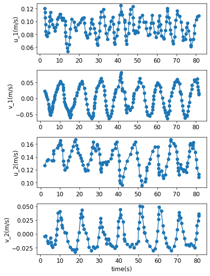

```python
#os.chdir(os.path.join('dataDir','comparison_data'))

UT1, U1 = readCSV_Ncol(os.path.join(dataDir,'comparison_data','SL_S1_U.DAT'),2,0)
VT1, V1 = readCSV_Ncol(os.path.join(dataDir,'comparison_data','SL_S1_V.DAT'),2,0)
UT2, U2 = readCSV_Ncol(os.path.join(dataDir,'comparison_data','SL_S2_U.DAT'),2,0)
VT2, V2 = readCSV_Ncol(os.path.join(dataDir,'comparison_data','SL_S2_V.DAT'),2,0)

os.chdir(MyDir)

fig,ax = plt.subplots(4,1,figsize=(6,8))
plt.rcParams['font.size'] = '12'
#plt.rcParams['font.weight'] = 'bold'

ax[0].plot(UT1,U1,'o-')
ax[0].set_ylabel('u_1(m/s)')
ax[1].plot(VT1,V1,'o-')
ax[1].set_ylabel('v_1(m/s)')
ax[2].plot(UT2,U2,'o-')
ax[2].set_ylabel('u_2(m/s)')
ax[3].plot(VT2,V2,'o-')
ax[3].set_ylabel('v_2(m/s)')
plt.xlabel('time(s)')
plt.tight_layout()
plt.savefig('results.png')
plt.show()
```

## Reading the BG_flood output

```
0.1057
```

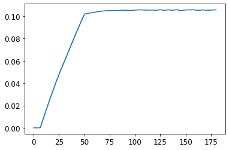

```python
Data_f = readCSV_Ncol('gauge_forcing.txt',5,1)
plt.plot(Data_f[0], Data_f[3])
Data_f[3][-1]
```

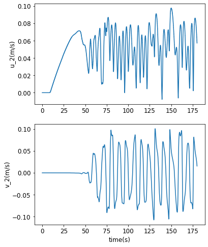

```python
Data_c = readCSV_Ncol('gauge_centered.txt',5,1)
fig,ax = plt.subplots(2,1,figsize=(6,8))
ax[0].plot(Data_c[0], Data_c[3])
ax[1].plot(Data_c[0], Data_c[4])
ax[0].set_ylabel('u_2(m/s)')
ax[1].set_ylabel('v_2(m/s)')
plt.xlabel('time(s)')
```

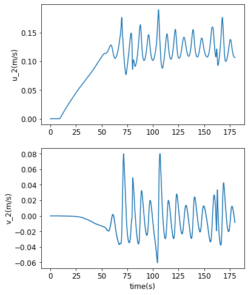

```python
Data_o = readCSV_Ncol('gauge_offset.txt',5,1)
fig,ax = plt.subplots(2,1,figsize=(6,8))
ax[0].plot(Data_o[0], Data_o[3])
ax[1].plot(Data_o[0], Data_o[4])
ax[0].set_ylabel('u_2(m/s)')
ax[1].set_ylabel('v_2(m/s)')
plt.xlabel('time(s)')
```

## Comparing the results with the benchmark

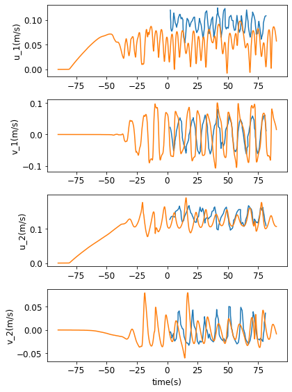

```python
fig,ax = plt.subplots(4,1,figsize=(6,8))
plt.rcParams['font.size'] = '12'
#plt.rcParams['font.weight'] = 'bold'

ax[0].plot(UT1,U1,'-')
ax[0].plot(Data_c[0]-90*np.ones(len(Data_c[0])), Data_c[3])
ax[0].set_ylabel('u_1(m/s)')
ax[1].plot(VT1,V1,'-')
ax[1].plot(Data_c[0]-90*np.ones(len(Data_c[0])), Data_c[4])
ax[1].set_ylabel('v_1(m/s)')
ax[2].plot(UT2,U2,'-')
ax[2].plot(Data_o[0]-90*np.ones(len(Data_c[0])), Data_o[3])
ax[2].set_ylabel('u_2(m/s)')
ax[3].plot(VT2,V2,'-')
ax[3].plot(Data_o[0]-90*np.ones(len(Data_c[0])), Data_o[4])
ax[3].set_ylabel('v_2(m/s)')
plt.xlabel('time(s)')
plt.tight_layout()
plt.savefig('results.png')
plt.show()
```